# Genetic_load_figures_Ppinaster_study

Thomas Francisco

2026-04-01

```r
library(dplyr)
library(writexl)
library(ggplot2)
library(tidyverse)
```

# 1 Introduction

This script analyses genetic load results in *P. pinaster* adults and juveniles in the Lacanau and Tocchi populations. The aim was to investigate the levels of number of deleterious mutations in homozygosis and heterozygosis across populations and to gain insight into the dynamics of these loads across cohorts.

The results were obtained from the genetic load calculation script using SNPeff and Provean softwares.

We computed each load type: realised, potential and total loads with and without correction for population genetic diversity.

# 2 Loading data

```r
Df_load_total_realised <- read.csv("Data/Chapter3/Pinus_pinaster/genetic_load/Ppinaster_chapter3_GL_all_stats_new.csv",h=T,sep=";",dec=",")

Df_load_total_realised_num <- data.frame(Indiv_ID=Df_load_total_realised$Indiv_ID,dplyr::mutate_all(Df_load_total_realised[,-1], function(x) as.numeric(as.character(x))))

#Load info on adults and juveniles
load("Results/Chapter3/Pinaster/Comparison_juveniles_adults/Data/combined_rda_data_Lacanau_LC.Rdata")
combined_rda_data_Lacanau_LC$Indiv_ID <- row.names(combined_rda_data_Lacanau_LC)

#Change name to match loads dataframe
combined_rda_data_Lacanau_LC$Indiv_ID <- ifelse(
  grepl("_0*(\\d{1,3})$", combined_rda_data_Lacanau_LC$Indiv_ID) & as.numeric(sub(".*_(\\d+)$", "\\1", combined_rda_data_Lacanau_LC$Indiv_ID)) <= 500,
  paste0(
    "FR_PP_62_",
    sub(".*_(\\d+)$", "\\1", combined_rda_data_Lacanau_LC$Indiv_ID),
    "-",
    combined_rda_data_Lacanau_LC$Indiv_ID
  ),
  combined_rda_data_Lacanau_LC$Indiv_ID
)

load("Results/Chapter3/Pinaster/Comparison_juveniles_adults/Data/combined_rda_data_Tocchi_LC.Rdata")
combined_rda_data_Tocchi_LC$Indiv_ID <- row.names(combined_rda_data_Tocchi_LC)

#Change name to match loads dataframe
num_suffix <- as.numeric(sub(".*_(\\d+)$", "\\1", combined_rda_data_Tocchi_LC$Indiv_ID))

#Only transform 1 to 500 to match label used in the other dataframe
combined_rda_data_Tocchi_LC$Indiv_ID <- ifelse(
  num_suffix <= 500,
  paste0(
    "IT_PP_63_",
    sprintf("%02d", num_suffix),
    "-",
    combined_rda_data_Tocchi_LC$Indiv_ID
  ),
  combined_rda_data_Tocchi_LC$Indiv_ID
)
```

Add the cohort information

```r
Df_load_total_realised_Lacanau <- merge(Df_load_total_realised_num,combined_rda_data_Lacanau_LC,"Indiv_ID")

Df_load_total_realised_Tocchi <- merge(Df_load_total_realised_num,combined_rda_data_Tocchi_LC,"Indiv_ID")
```

```r
Df_load_total_realised_Tocchi_correct_name <-
Df_load_total_realised_Tocchi_order <-

  write.csv(Df_load_total_realised_Lacanau, file="Results/Chapter3/Pinaster/Genetic_load_new_estimates/numbers/Df_load_total_realised_Lacanau.csv")
```

# 3 Realised load

The realised genetic load is expected to currently have an impact on the individual fitness as it corresponds to the expected deleterious mutations in homozygosis.

## 3.1 Ratio of realised load by dividing with the number of neutral mutations in homozygosis

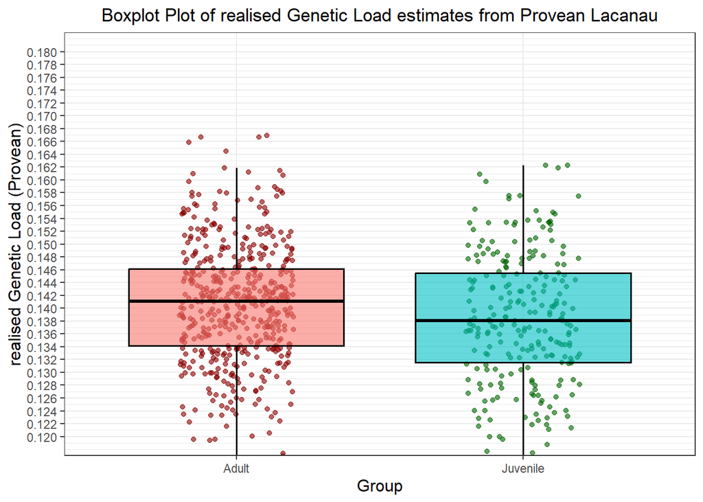

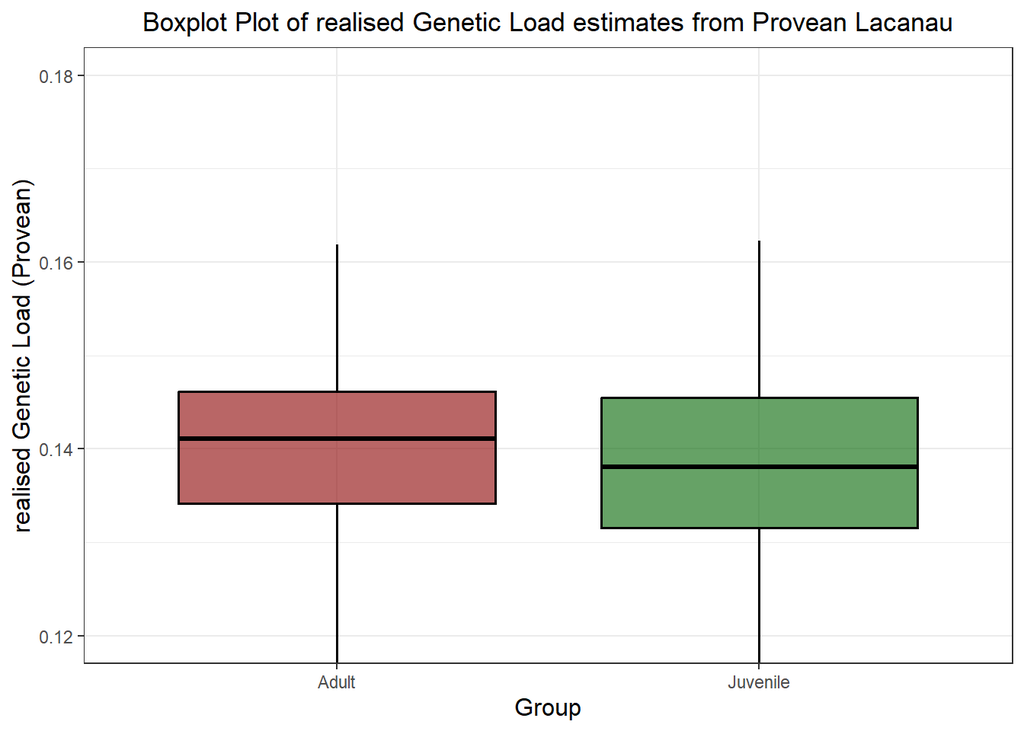

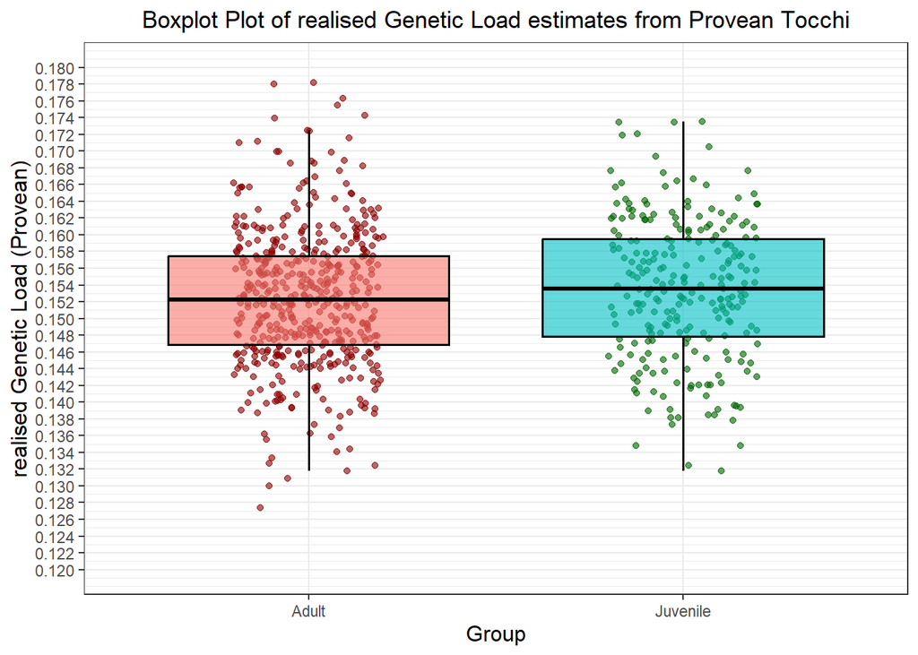

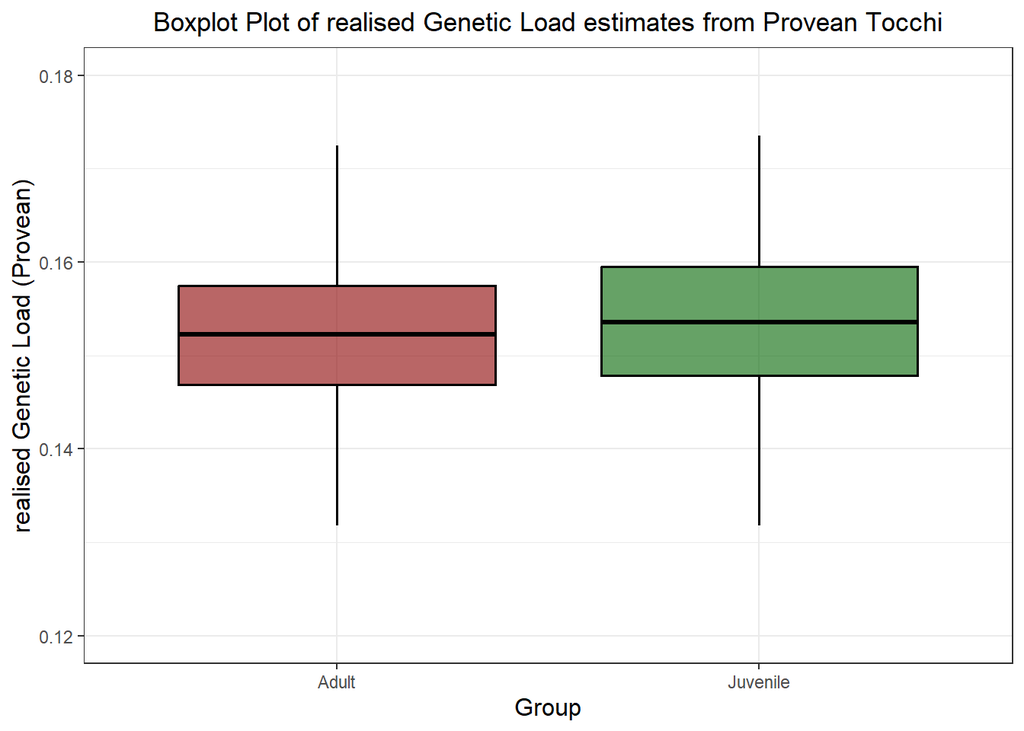

```r
list_plots <- c("Lacanau","Tocchi")

for(x in 1:length(list_plots)){

  plot <- list_plots[x]
  df_realised_load <- get(paste0("Df_load_total_realised_",plot))

  t_test_result <- t.test(Recessive_GLr ~ Group, data = df_realised_load)

    assign(paste0("realised_load_difference_across_adults_juv_",plot),t_test_result)

  #Plot
realised_load_boxplot <- ggplot(df_realised_load, aes(x = Group, y = Recessive_GLr, fill = Group)) +
  geom_jitter(aes(color = Group), width = 0.2, alpha = 0.6, size = 1.5, show.legend = FALSE) +
  geom_boxplot(outlier.shape = NA, alpha = 0.6, color = "black", size = 0.6) +
  scale_color_manual(values = c("darkred", "darkgreen")) +
  labs(
    title = paste0("Boxplot Plot of realised Genetic Load estimates from Provean ", plot),
    #x = "Group-age",
    y = "realised Genetic Load (Provean)"
  ) +
  coord_cartesian(ylim = c(0.12, 0.18)) +
  scale_y_continuous(breaks = seq(0.12, 0.18, by = 0.002)) +
  theme_bw() +
  theme(
    plot.title = element_text(hjust = 0.5),
    legend.position = "none",
    axis.text.x = element_text(angle = 0, hjust = 0.5),
    axis.title.x = element_text(size = 12),
    axis.title.y = element_text(size = 12)
  )

plot(realised_load_boxplot)

pdf(paste0("Results/Chapter3/Pinaster/Genetic_load_new_estimates/Comparison_adults_juveniles/realised/figures/GL_realised_boxplot_",plot,".pdf"), width = 8, height = 6)
print(realised_load_boxplot)
dev.off()

realised_load_boxplot_wo_points <- ggplot(df_realised_load, aes(x = Group, y = Recessive_GLr, fill = Group)) +
  #geom_jitter(aes(color = Group), width = 0.2, alpha = 0.6, size = 1.5, show.legend = FALSE) + #points
  geom_boxplot(outlier.shape = NA, alpha = 0.6, color = "black", size = 0.6) +
  scale_fill_manual(values = c("darkred", "darkgreen")) +
  scale_color_manual(values = c("darkred", "darkgreen")) +
  labs(
    title = paste0("Boxplot Plot of realised Genetic Load estimates from Provean ", plot),
    #x = "Group-age",
    y = "realised Genetic Load (Provean)"
  ) +
  coord_cartesian(ylim = c(0.12, 0.18)) +
  scale_y_continuous(breaks = seq(0.12, 0.18, by = 0.02)) +
  theme_bw() +
  theme(
    plot.title = element_text(hjust = 0.5),
    legend.position = "none",
    axis.text.x = element_text(angle = 0, hjust = 0.5),
    axis.title.x = element_text(size = 12),
    axis.title.y = element_text(size = 12)
  )

plot(realised_load_boxplot_wo_points)

pdf(paste0("Results/Chapter3/Pinaster/Genetic_load_new_estimates/Comparison_adults_juveniles/realised/figures/GL_realised_boxplot_wopoints_",plot,".pdf"), width = 8, height = 6)
print(realised_load_boxplot_wo_points)
dev.off()

}
```

```r
print(realised_load_difference_across_adults_juv_Lacanau)
```

```
##
##  Welch Two Sample t-test
##
## data:  Recessive_GLr by Group
## t = 2.8627, df = 465.53, p-value = 0.00439
## alternative hypothesis: true difference in means between group Adult and group Juvenile is not equal to 0
## 95 percent confidence interval:
##  0.0006861206 0.0036902345
## sample estimates:
##    mean in group Adult mean in group Juvenile
##              0.1405309              0.1383428
```

```r
print(realised_load_difference_across_adults_juv_Tocchi)
```

```
##
##  Welch Two Sample t-test
##
## data:  Recessive_GLr by Group
## t = -1.6357, df = 491.03, p-value = 0.1026
## alternative hypothesis: true difference in means between group Adult and group Juvenile is not equal to 0
## 95 percent confidence interval:
##  -0.0023265071  0.0002126885
## sample estimates:
##    mean in group Adult mean in group Juvenile
##              0.1523823              0.1534392
```

We computed the realised load without normalising by the number of neutral homozygous sites because comparisons were performed among individuals within the same population, which are expected to share a common demographic history and similar levels of neutral genetic variation.

Graph with final colors.

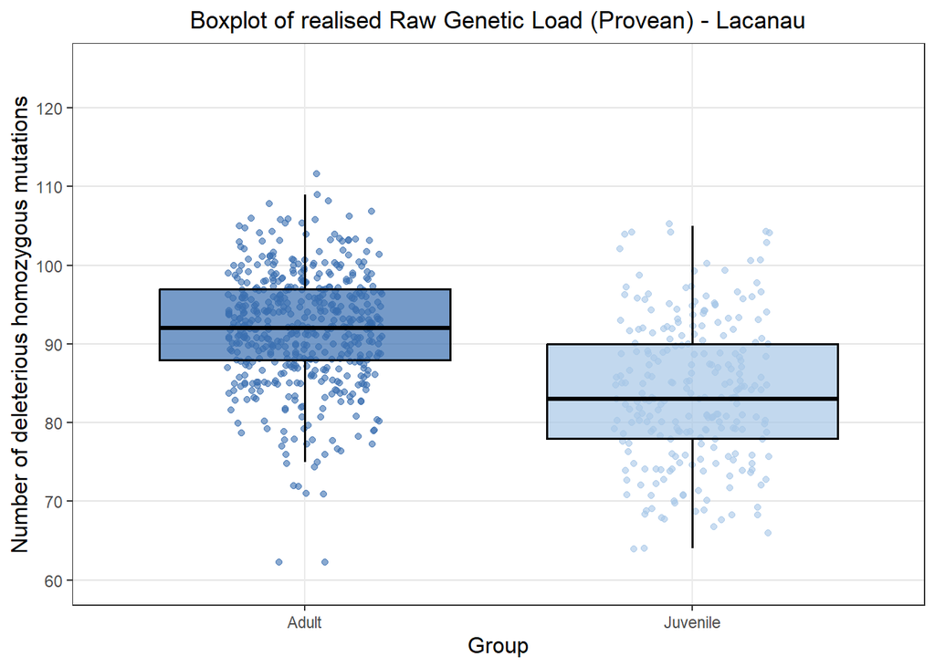

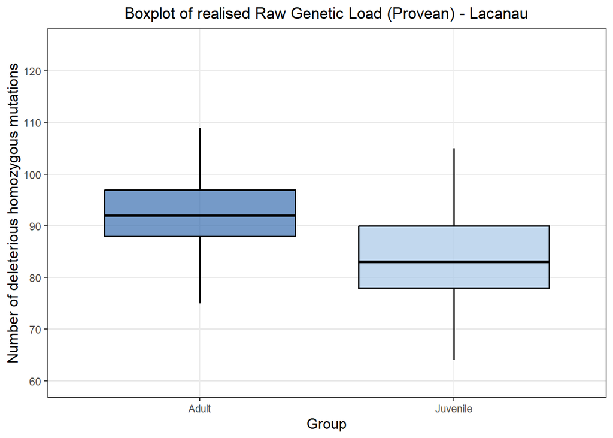

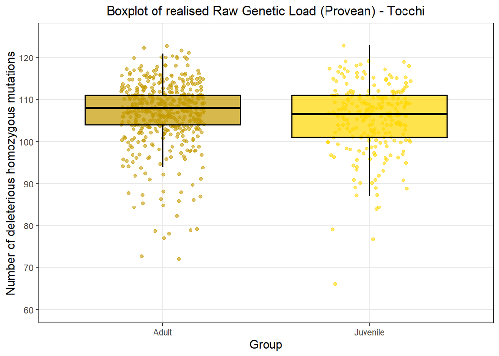

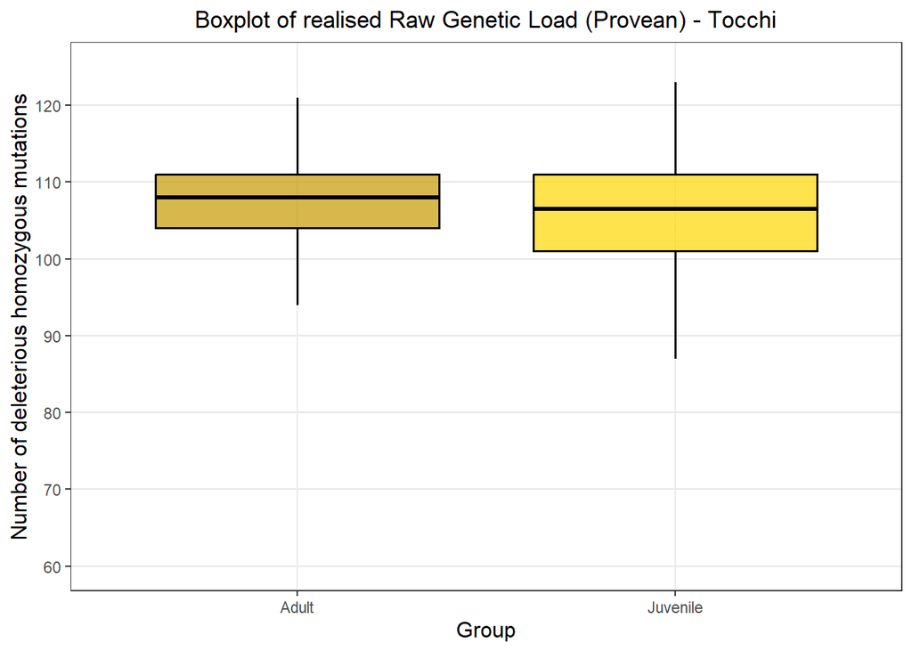

```r
list_plots <- c("Lacanau","Tocchi")

#Define color lists
color_list <- list(
  Lacanau = c(
    Adult = "#3A6FB0",
    Juvenile = "#A7C7E7"
  ),
  Tocchi = c(
    Adult = "#C49A00",
    Juvenile = "#FFD700"
  )
)

for(x in 1:length(list_plots)){

  plot <- list_plots[x]
  df_realised_load <- get(paste0("Df_load_total_realised_",plot))

  #Run t-test
  t_test_result <- t.test(Homozygous_deleterious_counts ~ Group, data = df_realised_load)
  assign(paste0("raw_realised_load_difference_across_adults_juv_",plot), t_test_result)

  #Select correct color palette
  col_pal <- color_list[[plot]]

  #Boxplot
  raw_realised_load_boxplot <- ggplot(df_realised_load,
                                       aes(x = Group,
                                           y = Homozygous_deleterious_counts,
                                           fill = Group)) +
    geom_jitter(aes(color = Group), width = 0.2, alpha = 0.6, size = 1.5, show.legend = FALSE) +
    geom_boxplot(outlier.shape = NA, alpha = 0.7, color = "black", size = 0.6) +
    scale_fill_manual(values = col_pal) +
    scale_color_manual(values = col_pal) +
    labs(
      title = paste0("Boxplot of realised Raw Genetic Load (Provean) - ", plot),
      y = "Number of deleterious homozygous mutations"
    ) +
    coord_cartesian(ylim = c(60, 125)) +
    scale_y_continuous(breaks = seq(60, 125, by = 10)) +
       theme_bw() +
theme(
  panel.grid.minor.y = element_blank(),
  panel.grid.minor.x = element_blank(),
  panel.grid.major.y = element_line(color="grey90"),
  plot.title = element_text(hjust = 0.5),
  legend.position = "none",
  axis.text.x = element_text(angle = 0, hjust = 0.5),
  axis.title.x = element_text(size = 12),
  axis.title.y = element_text(size = 12)
)

  plot(raw_realised_load_boxplot)

  #Save plot
  pdf(paste0("Results/Chapter3/Pinaster/Genetic_load_new_estimates/Comparison_adults_juveniles/realised/figures/GL_raw_realised_boxplot_",plot,".pdf"),
      width = 8, height = 6)
  print(raw_realised_load_boxplot)
  dev.off()

  #Boxplot without individual points
  raw_realised_load_boxplot_wo_points <- ggplot(df_realised_load,
                                                 aes(x = Group,
                                                     y = Homozygous_deleterious_counts,
                                                     fill = Group)) +
    geom_boxplot(outlier.shape = NA, alpha = 0.7, color = "black", size = 0.6) +
    scale_fill_manual(values = col_pal) +
    labs(
      title = paste0("Boxplot of realised Raw Genetic Load (Provean) - ", plot),
      y = "Number of deleterious homozygous mutations"
    ) +
    coord_cartesian(ylim = c(60, 125)) +
    scale_y_continuous(breaks = seq(60, 125, by = 10)) +
    theme_bw() +
      theme_bw() +
theme(
  panel.grid.minor.y = element_blank(),
  panel.grid.minor.x = element_blank(),
  panel.grid.major.y = element_line(color="grey90"),
  plot.title = element_text(hjust = 0.5),
  legend.position = "none",
  axis.text.x = element_text(angle = 0, hjust = 0.5),
  axis.title.x = element_text(size = 12),
  axis.title.y = element_text(size = 12)
)

  plot(raw_realised_load_boxplot_wo_points)

  #Save plot without points
  pdf(paste0("Results/Chapter3/Pinaster/Genetic_load_new_estimates/Comparison_adults_juveniles/realised/figures/GL_raw_realised_boxplot_wopoints_",plot,".pdf"),
      width = 8, height = 6)
  print(raw_realised_load_boxplot_wo_points)
  dev.off()
}
```